# Статистическое оценивание в R

Lulin Dmitry

2024-11-22

### 1.1 Импорт данных для работы

Подключаем необходимый для импорта данных пакет.

```r
library('rio')
```

Далее импортируем файл с общими данными и выбираем столбец нашей выборки.

```r
dataframe <- import('R_data.xlsx')
```

```r
data <- dataframe['v17']
```

Теперь выведем первые и последние 5 значений по выборке

```r
head(data)
```

```
##     v17
## 1   102
## 2 101.2
## 3 101.3
## 4 100.8
## 5 105.5
## 6 104.6
```

```r
tail(data)
```

```
##       v17
## 96  105.3
## 97  103.5
## 98  101.5
## 99  103.7
## 100 102.8
## 101   v17
```

Используем функцию `str`, чтобы получить краткую информацию о наших данных

```r
str(data)
```

```
## 'data.frame':    101 obs. of  1 variable:
##  $ v17: chr  "102" "101.2" "101.3" "100.8" ...
```

Данные успешно импортированы. Теперь необходимо привести их к виду, при котором мы сможем использовать функции статистического анализа R.

### 1.2. Подготовка данных для статистического анализа

```r
data <- data[1:100,]
```

Преобразуем данные в числовой формат для дальнейшей работы.

```r
data <- as.data.frame(as.numeric(data))
```

Переименуем столбец данных в соответствии с исследуемой величиной:

```r
names(data) <- 'Объем основных фондов'
```

И снова посмотрим первые и последние пять значений по выборке:

```r
head(data)
```

```
##   Объем основных фондов
## 1                 102.0
## 2                 101.2
## 3                 101.3
## 4                 100.8
## 5                 105.5
## 6                 104.6
```

```r
tail(data)
```

```
##     Объем основных фондов
## 95                  104.9
## 96                  105.3
## 97                  103.5
## 98                  101.5
## 99                  103.7
## 100                 102.8
```

Проверим структуру исправленных данных:

```r
str(data)
```

```
## 'data.frame':    100 obs. of  1 variable:
##  $ Объем основных фондов: num  102 101 101 101 106 ...
```

### 1.3. Дескриптивная статистика

Получим начальное представление об исследуемой величине по имеющейся выборке:

```r
summary(data)
```

```
##  Объем основных фондов
##  Min.   :100.2
##  1st Qu.:102.3
##  Median :103.5
##  Mean   :103.7
##  3rd Qu.:105.0
##  Max.   :109.6
```

В результате мы получили минимальное значение в выборке, выборочные нижний квартиль, медиану, среднюю, верхний квартиль, максимальное значение в выборке.

Более подробно о распределении изучаемого признака можно узнать, используя функцию Desc пакета DescTools:

```r
library("DescTools")
```

```r
Desc(data)
```

```
## ──────────────────────────────────────────────────────────────────────────────
## Describe data (data.frame):
##
## data frame:  100 obs. of  1 variables
##      100 complete cases (100.0%)
##
##   Nr  Class  ColName                NAs  Levels
##   1   num    Объем основных фондов  .
##
##
## ──────────────────────────────────────────────────────────────────────────────
## 1 - Объем основных фондов (numeric)
##
##    length        n      NAs   unique       0s     mean   meanCI'
##       100      100        0       52        0  103.695  103.318
##             100.0%     0.0%              0.0%           104.072
##
##       .05      .10      .25   median      .75      .90      .95
##   101.095  101.290  102.275  103.550  104.950  106.200  106.910
##
##     range       sd    vcoef      mad      IQR     skew     kurt
##     9.400    1.902    0.018    2.002    2.675    0.539    0.026
##
## lowest : 100.2, 100.5, 100.8 (2), 101.0, 101.1
## highest: 107.1, 107.8, 108.3, 108.4, 109.6
##
## ' 95%-CI (classic)
```

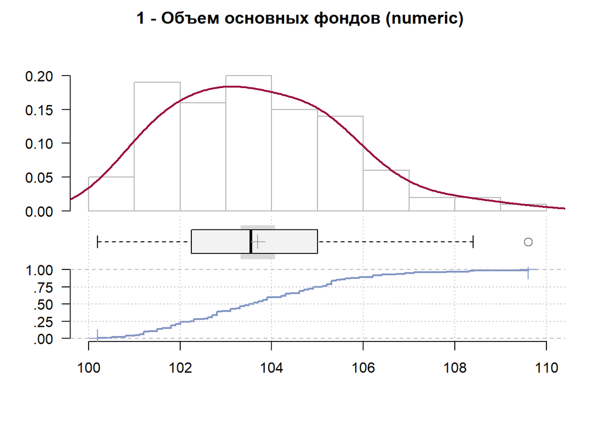

*Рис. 1. Гистограмма, ящичковая диаграмма и кумулята исследуемой переменной, выдаваемые функцией `Desc` пакета DescTools*

В результате мы получаем таблицу с кратким описанием признаков, имеющихся в датафрейме. Также мы получаем расширенную дескриптивную статистику для каждого признака в датафрейме: объем выборки, выборочную среднюю, доверительный интервал для средней, используя оценку среднеквадратического отклонения, размах вариации и др. Также получили три графика: ящик с усами, гистограмму плотности и подогнанную с помощью непараметрических методов кривую плотности распределения, кумуляту относительных частот.

Для удобства дальнейшего анализа запишем данные в вектор под именем volume, а также создадим переменную с объёмом выборки n:

```r
volume <- data[[1]]
```

```r
n <- length(volume)
```

### 1.4. Гистограмма эмпирических частот

Построим гисторамму эмпирических частот:

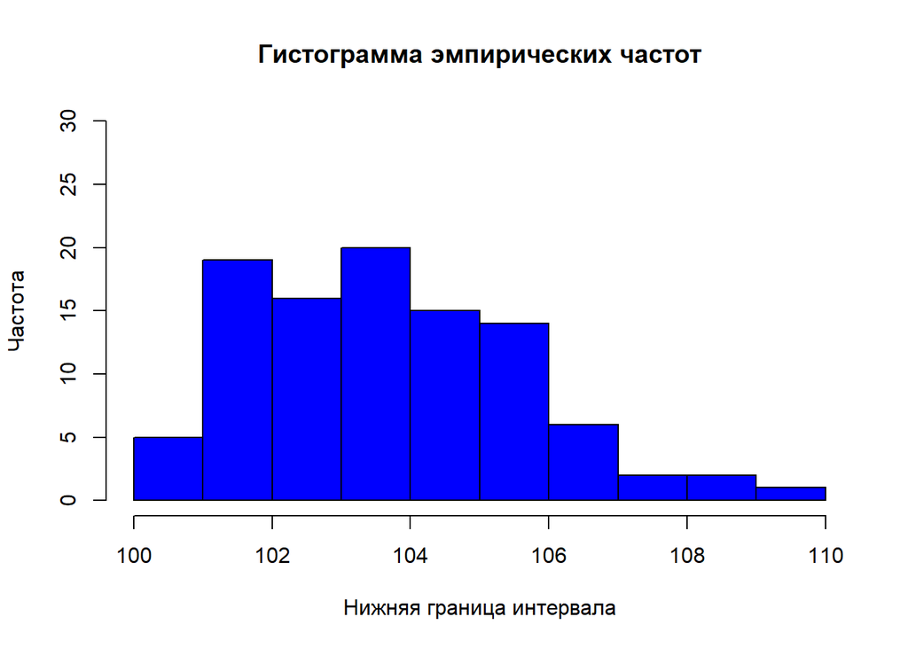

```r
hist = hist(volume, freq = TRUE, col = 'blue', breaks = 'sturges', xlab = 'Нижняя граница интервала',  ylab = 'Частота', ylim = c(0, 30), main = 'Гистограмма эмпирических частот')
```

Смотря на полученные результаты, можем увидеть, что гистограмма имеет существенную правостороннюю ассиметрию.

Теперь нанесем теоретическую кривую нормального закона на гистограмму частот:

```r
x_values <- seq(from = min(volume)-0.1,to = max(volume)+0.1,length = 1000)
```

```r
h = unlist(hist['breaks'])[2]-unlist(hist['breaks'])[1]
```

```r
y_values <- dnorm(x_values, mean = mean(volume), sd = sd(volume))*h*n
```

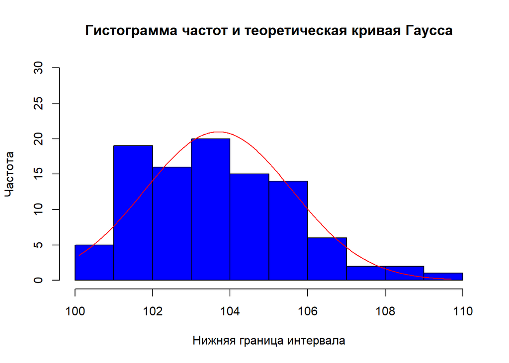

*Рис. 3. Гистограмма эмпирических частот объема основных фондов и теоретическая кривая нормального распределения, построенные с помощью базовой функции* `hist`

```r
hist = hist(volume, freq = TRUE, col = 'blue', breaks = 'sturges', xlab = 'Нижняя граница интервала',  ylab = 'Частота', ylim = c(0, 30), main = 'Гистограмма частот и теоретическая кривая Гаусса')
lines(x_values, y_values, col = 'red')
```

По полученному графику можем увидеть, что теоретическая кривая Гаусса не совпадает с гистограммой эмпирических частот.

### 1.5. Интервальные оценки параметров нормального распределения

Зададим сперва надежность, с которой будем строить все интервальные оценки параметров:

```r
gamma = 0.99
```

В предположении, что значение генерального среднеквадратического отклонения 𝜎(𝑋) = 0,2, построим доверительный интервал для средней, используя функцию `MeanCI`:

```r
MeanCI(volume, sd = 0.2, conf.level = gamma)
```

```
##     mean   lwr.ci   upr.ci
## 103.6950 103.6435 103.7465
```

Первое значение результата вызова функции соответствует точечной оценке средней – среднему арифметическому $x$ = 103.6950, второе - нижней границе доверительного интервала, третье - верхней границе интервала.

Таким образом, при известной генеральной дисперсии интервальная оценка генеральной средней: (103.6435 ≤ 𝜇 ≤ 103.7465) = 0.99

Теперь рассмотрим случай, когда генеральное СКО неизвестно:

```r
MeanCI(volume, conf.level = gamma)
```

```
##     mean   lwr.ci   upr.ci
## 103.6950 103.1953 104.1947
```

Здесь среднее арифметическое $x$ = 103.6950, а интервальная оценка: (103.1953 ≤ 𝜇 ≤ 104.1947) = 0.99

Как мы можем видеть, при неизвестном среднеквадротическом отклонении ширина доверительного интервала существенно увеличилась, примерно в 10 раз.

Доверительный интервал для дисперсии можно найти, воспользовавшись функцией `VarCI`, указав дополнительным аргументом метод `norm`:

```r
VarCI(volume, conf.level = gamma, method = 'norm')
```

```
##      var   lwr.ci   upr.ci
## 3.619470 2.330257 4.968883
```

Для нахождения доверительного интервала для СКО, придется написать код вручную:

```r
sdCI <- c(sd(volume)*sqrt(2*n)/(sqrt(2*n - 3) + qnorm(1-(1-gamma)/2)), sd(volume)*sqrt(2*n)/(sqrt(2*n - 3) - qnorm(1-(1-gamma)/2)))
names(sdCI) <- c('sd_min', 'sd_max')
sdCI
```

```
##   sd_min   sd_max
## 1.619678 2.347788
```

В итоге мы получили асимптотический доверительный интервал для генерального среднего квадратического отклонения:

𝑃(1.619678 ≤ 𝜎 ≤ 2.347788) = 0.99

### 1.6. Интервальные оценки вероятности (генеральной доли) биномиального распределения

Условие задачи: найти с надежностью 0,95 границы, в которых будет лежать доля приборов, проработающих без отказа в случае, если из 200 случайно отобранных приборов 120 проработало безотказно.

Запишем условия задачи в среду программирования для дальнейшего анализа.

```r
n1 = 200 # число испытаний в партии
m1 = 120 # число успехов в партии
gamma = 0.95 # надежность
```

В первом пункте мы имеем достаточно большую выборку, следовательно используем функцию `BinomCI` пакета `DescTools`, указав обязательные аргументы, требуемую надежность и метод Вальда:

```r
BinomCI(m1, n1, conf.level=gamma, method = 'wald')
```

```
##      est    lwr.ci    upr.ci
## [1,] 0.6 0.5321049 0.6678951
```

Заметим, что помимо условия большого числа испытаний для использования интервала Вальда накладывается также ограничение на предполагаемое значение вероятности.

Также при большом числе испытаний можно рассмотреть интервал Агрести Коула, и в нашем случае он дал интервал с несущественно меньшей шириной (разцина начинается с тысячных долей ширины):

```r
BinomCI(m1, n1, conf.level=gamma, method = 'agresti-coull')
```

```
##      est    lwr.ci    upr.ci
## [1,] 0.6 0.5308108 0.6654201
```

Условие второго пункта: найти с надежностью 0,95 границы, в которых будет лежать доля приборов, проработающих без отказа в случае, если из 10 случайно отобранных приборов 5 проработало безотказно.

В связи с малым объемом выборки мы будем использовать другие методы (для начала метод Клоппера-Пирсона) при той же функции.

```r
n2 = 10 # число испытаний в партии
m2 = 5 # число успехов в партии
BinomCI(m2, n2, conf.level=gamma, method = 'clopper-pearson')
```

```
##      est   lwr.ci   upr.ci
## [1,] 0.5 0.187086 0.812914
```

```r
BinomCI(m1, n1, conf.level=gamma, method = 'wilson')
```

```
##      est    lwr.ci    upr.ci
## [1,] 0.6 0.5308367 0.6653942
```

```r
BinomCI(m1, n1, conf.level=gamma, method = 'jeffreys')
```

```
##      est    lwr.ci    upr.ci
## [1,] 0.6 0.5310687 0.6660604
```

Подводя итоги по проделанной работе, я познакомился с несколькими важными для анализа данных библиотека и внутренними функциями, рассчитывающими выборочные характеристики и визуализирующими полученный результат. Научился строить доверительные интервалы для генерального матожидания, дисперсии и СКО, а также генеральной доли.